# Spatial Data Wrangling

Vector data is essentially object data meaning any real world thing like a tree, building, forest, etc. can be considered an object and therefore vector.

The two main packages that deal with vector data in R:

- **sp:** the original spatial package in R (first released in 2005) that has a complex data structure
- **sf:** much newer, so not as well established as **sp**, but it is easier to use than sp and is tidy friendly

SF stands for “simple feature”. It sees any real-word object (or vector) as a feature and a feature can have both a geometry of where the feature is located and attributes associated with it. For example, a county is a feature with a polygon shape and can have attributes like population, number of hospitals, etc. associated with it. Another example could be a UC Davis, which would have a point geometry.

# Mapping trees in Davis Example

I am curious about the spatial distribution of fruit trees in Davis. In order to examine this, we will need to bring in the geography of the City of Davis, as well as point data from fallingfruit.org

Step one: Bring in all datasets. In our case, we are going to use three sources of data: 1) City of Davis boundary, 2) census tract data for population and median housing value, and 3) fallenfruit.org fruit tree locations.

```r
# You will need to sign up for a Census API Key if you are intersted in pulling in US Census data
## Request an API key here: https://api.census.gov/data/key_signup.html
#census_api_key("3f1a61d7b9d2f870de53940d461dda896938261b", install = TRUE) #now stored in my R environment

# Pull in in places data
pl <- places(state = "CA", year = 2020, cb = FALSE)

glimpse(pl)

# Now let's just isolate the boundary for the City of Davis

davis <- pl %>%
  filter(NAME == "Davis")

glimpse(davis)

# Let's also pull in some census tract data from the City of Davis
## first, let's look at what variables are available
v20 <- load_variables(2020, "acs5", cache=TRUE) # load variable options

## Now that we have chosen our variables of interest, let's pull in that data
ca.tracts <- get_acs(
      geography = "tract",
      year = 2020, # final year
      variables = c(totp = "B01003_001", #median income
                    medhouse = "B25077_001"), #Median housing value for owner-occupied housing units
      state = "CA",
      output= "wide",
      survey = "acs5", #this loads the data from the last 5 years of acs records
      geometry = TRUE,
      cb = FALSE
      )

### Now I am only interested in Davis census tracts, so I will use the city of davis boundary to clip the tracts
davis.tracts <- ms_clip(target = ca.tracts, clip = davis, remove_slivers = TRUE)

## Now bring in fallingfruit.org
### I went onto the website and directly downloaded the csv file
fruit <- read.csv("data/data.csv")
```

Both GCS and PCS need to be specified when working with spatial data! In order to do this, you will first need to find out what CRS your spatial dataset was created in initially.

```r
# Check CRS of all three datasets
class(davis)
st_crs(davis) #NAD83
st_crs(davis)$proj4string #"+proj=longlat +datum=NAD83 +no_defs"
st_crs(davis)$units #NULL

st_crs(davis.tracts) #NAD83
st_crs(davis.tracts)$proj4string #"+proj=longlat +datum=NAD83 +no_defs"
st_crs(davis.tracts)$units #NULL

st_crs(fruit) #NA
st_crs(fruit)$proj4string #NA

# So we can see that both the davis and ca.tracts dataframes are in NAD 83, so let's reproject the fruit dataframe to also be in this projection

# Reprojection
## First, establish the CRS for the fruit dataset based on how it was created intially
## Since fruit is point data, the projected coordinate system is already set because latitude and longitude are the X-Y coordinates but we need to tell R this
fruit.sf <- fruit %>%
  st_as_sf(coords = c("lng", "lat"),
           crs = "+proj=longlat +datum=WGS84 +ellps=WGS84")
st_crs(fruit.sf)# +proj=longlat +datum=WGS84 +ellps=WGS84

## Now let's reproject so it is on the same coordinate system as the other dataframes
### By transform to proj = utm, now the CRS can handle distance measures
### UTM: Universal Transverse Mercator works in meters
fruit.utm <- fruit.sf %>%
  st_transform(crs = "+proj=utm +zone=10 +datum=NAD83 +ellps=GRS80")

## Reproject davis and ca.tracts to also be in UTM
davis.utm <- davis %>%
  st_transform(crs = "+proj=utm +zone=10 +datum=NAD83 +ellps=GRS80")

davis.tracts.utm <- davis.tracts %>%
  st_transform(crs = "+proj=utm +zone=10 +datum=NAD83 +ellps=GRS80")

# Great, nows lets check to see if all dataframes are on the same CRS
st_crs(fruit.utm) == st_crs(davis.utm) #TRUE

st_crs(davis.utm) == st_crs(davis.tracts.utm) #TRUE
```

Finally, we are the point where we can map the data! For this example, I outline how to use tmap to do this.

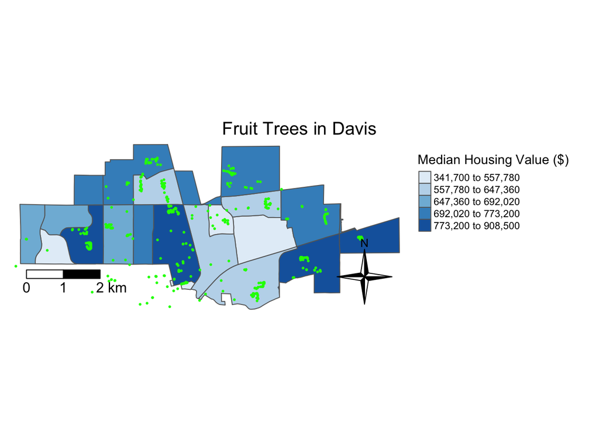

```r
# Map the point data over the census tract data
tm_shape(davis.tracts.utm) +
  tm_polygons(col = "medhouseE", style = "quantile", palette = "Blues",
              title = "Median Housing Value ($)") +
  tm_shape(fruit.utm) +
  tm_dots(col = "green") +
  #tm_text("types") +
    tm_scale_bar(breaks = c(0, 1, 2), text.size = 1, position = c("left", "bottom")) +
      tm_compass(type = "4star", position = c("right", "bottom"))  +
  tm_layout(main.title = "Fruit Trees in Davis",
            main.title.size = 1.25, main.title.position="center",
            legend.outside = TRUE, legend.outside.position = "right",
            frame = FALSE)
```